[figure not shown]

## UNIVERSIDAD NACIONAL AGRARIA LA MOLINA

### Facultad de Ciencias Económicas

### Escuela Profesional de Estadística

# **MODELANDO EL TIPO DE CAMBIO PERUANO 1995-2025 MEDIANTE ARCH-GARCH**

Curso: Series de Tiempo  
Docente: Dr. Rino Sotomayor  
Estudiantes: Percy Quispe Ccari & Augusto Briceño Castro  
Ciclo: 2025-I

Lima, Perú - 25 de julio de 2025

# INTRODUCCIÓN

Los formuladores de políticas necesitan pronosticos precisos sobre los valores futuros de los tipos de cambio. Esto se debe al hecho de que la volatilidad del tipo de cambio es una medida de incertidumbre util sobre el entorno económico de un país. El presente estudio tuvo como objetivo determinar el comportamiento volatil del tipo de cambio mensual del dólar en el Perú en el periodo de Enero 1995 hasta mayo del 2025. El documento revela que la serie de tipo de cambio exhibe regularidades empíricas como volatilidad agrupada, no estacionariedad, no normalidad y correlacion serial que justifican la aplicación de la metodología ARCH. Se determino que existe un comportamiento volátil simétrico que es explicado por el modelo GARCH(1,1). Esto sugiere que el comportamiento del tipo de cambio generalmente esta influenciado por información de su comportamiento previo. Esto implica que la volatilidad del tipo de cambio del mes anterior puede afectar su volatilidad actual. La principal implicacion política de estos resultados es que, dado que la volatilidad del tipo de cambio (riesgo de tipo de cambio) puede aumentar los costos de transaccion y reducir las ganancias para el comercio internacional. El conocimiento de la estimacion y el pronóstico de la volatilidad del tipo de cambio es importante para la fijacion de precios y la gestión de riesgos.

# MARCO TEORICO

Se han desarrollado varios modelos en la literatura de finanzas empíricas para investigar la volatilidad en diferentes regiones y países. Los modelos más comunmente aplicados para estimar la volatilidad del tipo de cambio son el modelo autorregresivo condicional heteroscedastico (ARCH) introducido por (Engle, 1982) y los modelos generalizados (GARCH) desarrollados independientemente por (Bollerslev, 1986). El proposito del modelo autorregresivo de heterocedasticidad condicional (ARCH) es estimar la varianza condicional de una serie temporal. Engle describío la varianza condicional mediante una funcion cuadrática simple de sus valores rezagados. Bollerslev extendio el modelo ARCH basico y describío la varianza condicional por sus propios valores rezagados y el cuadrado de los valores rezagados de las innovaciones o los shocks.

## MODELOS DE VOLATILIDAD

### Modelo ARCH

En el modelo ARCH, la autocorrelación de la volatilidad se modela permitiendo que la varianza condicional del término de error dependa del valor inmediatamente anterior del error al cuadrado (Brooks, 2019), es decir:

$$\sigma_t^2 = \alpha_0 +
\alpha_1\varepsilon_{t-1}^2\tag{1}$$

Aquí, $\varepsilon_t$ se distribuye normalmente con media cero y $var(\varepsilon_t) = \alpha_0 + \alpha_1\varepsilon_{t-1}^2$, es decir, $\varepsilon_t \sim \mathcal{N}(0, \alpha_0 + \alpha_1\varepsilon_{t-1}^2)$ $\alpha_0$ y $\alpha_1$ son parámetros desconocidos. En otras palabras, la ecuación (1) establece que la varianza de la variable aleatoria $\varepsilon_t$ sigue un proceso ARCH(1), ya que la varianza condicional depende solo de un error cuadrático rezagado. Bajo ARCH, la ecuación que describe cómo $r_t$ varía con el tiempo (la ecuación media) podría tomar cualquier forma (Brooks, 2019). A efectos de este documento, el modelo completo se expresa como:

$r_{t} = \mu + \varepsilon_{t}, \quad \varepsilon_{t} \sim N(0,\sigma_{t}^{2}) \tag{2}$

$$\sigma_{t}^{2} = \alpha_{0} +
\alpha_{1}\varepsilon_{t-1}^{2}$$

$r_t$ puede ser un ARIMA(p,d,q) y $\alpha_{0} \geq 0$ y $\alpha_{1} \geq 0$. Dado que $\sigma_{t}^{2}$ es una varianza condicional, su valor siempre debe ser estrictamente positivo. Sin embargo, la varianza del error puede depender no solo de un error al cuadrado rezagado, sino también de varios errores al cuadrado rezagados. Por lo tanto, el modelo (2) puede extenderse al caso general donde la varianza del error depende de $p$ rezagos de error al cuadrado.

$$r_{t} = \mu + \varepsilon_{t}, \quad \varepsilon_{t} \sim N(0,\sigma_{t}^{2})$$

$\sigma_{t}^{2} = \alpha_{0} + \alpha_{1}\varepsilon_{t-1}^{2} + \alpha_{2}\varepsilon_{t-2}^{2} + \cdots + \alpha_{q}\varepsilon_{t-p}^{2}\tag{3}$

donde $\alpha_{0} > 0$, y $\alpha_{i} \geq 0$ para $i>0$. Los coeficientes $\alpha_{i}$ deben satisfacer algunas condiciones de regularidad para asegurar que la varianza incondicional de $\varepsilon_{t}$ sea finita.

### Modelo GARCH(1,1)

Modela la varianza condicional como combinación de un término constante (ω), el impacto del choque inmediato y el efecto de memoria, tal como se muestra a continuación:

$$v_t^2 = \omega + \alpha \cdot \varepsilon_{t-1}^2 + \beta \cdot v_{t-1}^2$$

$$\varepsilon_t^2 = v_t^2 + u_t$$

$$L(\mu, \alpha, \beta, \omega) = \frac{1}{v_t \cdot \sqrt{2\pi}} \cdot e^{- \frac{\varepsilon_t^2}{2 v_t^2}}$$

Donde:

𝑣<sup>2</sup><sub>t</sub> — variación del rendimiento condicional;

𝜔 — valor constante;

𝛼 — coeficiente de regresión considerando el efecto ARCH;

𝛽 — coeficiente de regresión considerando el efecto GARCH;

𝜀 — parámetro que contabiliza la desviación del modelo.

**EGARCH(1,1)**

incorpora un término logarítmico y un parámetro asimétrico que permite recoger la diferente reacción de la volatilidad ante noticias positivas y negativas.

$$\text{Log } v_t^2 = \omega + \alpha * \frac{|\epsilon_{t-1}|}{v_{t-1}} + \theta * \frac{\epsilon_{t-1}}{v_{t-1}} + \beta * \text{log } v_{t-1}^2$$

$$\epsilon_t^2 = v_t^2 + u_t$$

$$L_{(\mu, \alpha, \beta, \omega)} = \frac{1}{v_t * \sqrt{2 * \pi}} * e^{-\frac{\epsilon_t^2}{2v_t^2}}$$

𝑣<sup>2</sup><sub>t</sub> —variación del rendimiento condicional;

𝜔 — valor constante;

𝛼 — coeficiente de regresión considerando el efecto ARCH;

𝛽 — coeficiente de regresión considerando el efecto GARCH;

𝜀 — parámetros que contabilizan la desviación del modelo;

𝜃 — coeficiente de regresión teniendo en cuenta el efecto del apalancamiento.

**GARCH-M(1,1)**

Introduce la varianza condicional directamente en la ecuación de la media, testando la relación rentabilidad‑riesgo.

$$v_t^2 = \omega + \alpha * \epsilon_{t-1}^2 + \beta * v_{t-1}^2$$

$$\epsilon_t^2 = v_t^2 + u_t$$

$$L_{(\mu, \alpha, \beta, \omega)} = \frac{1}{v_t * \sqrt{2 * \pi}} * e^{-\frac{\epsilon_t^2}{2v_t^2}}$$

$$r_t = \mu + \delta * v_t^2 + \epsilon_t$$

$$r_t = \mu + \delta * v_t + \epsilon_t$$

Donde:

𝑣<sup>2</sup><sub>t</sub> — variación del rendimiento condicional;

𝜔 — valor constante;

𝛼 — coeficiente de regresión considerando el efecto ARCH;

𝛽 — coeficiente de regresión considerando el efecto GARCH;

𝜀 — parámetro que contabiliza la desviación del modelo.

**TGARCH(1,1)**

Añade un parámetro θ que se activa solo cuando los choques son negativos, recogiendo efectos *leverage* o de cola izquierda.

$$v_t^2 = \omega + \alpha * \epsilon_{t-1}^2 + \theta * \epsilon_{t-1}^2 * I \left( \epsilon_{t-1}^2 < 0 \right) + \beta * v_{t-1}^2$$

$$\epsilon_t^2 = v_t^2 + u_t$$

$$L_{(\mu, \alpha, \beta, \omega)} = \frac{1}{v_t * \sqrt{2 * \pi}} * e^{-\frac{\epsilon_t^2}{2v_t^2}}$$

Donde:

𝑣<sup>2</sup><sub>t</sub> — variación del rendimiento condicional;

𝜔 — valor constante;

𝛼 — coeficiente de regresión considerando el efecto ARCH;

𝛽 — coeficiente de regresión considerando el efecto GARCH;

𝜀 — parámetros que contabilizan la desviación del modelo;

𝜃 — coeficiente de regresión teniendo en cuenta el efecto del apalancamiento.

# METODOLOGIA

La investigación fue correlacional-longitudinal, y analiza el comportamiento de una serie temporal generada por un proceso estocástico. Se definió como población al proceso estocástico que genera el comportamiento aleatorio de la serie temporal del Tipo de Cambio del Dólar en el Perú en el periodo 1995-2025. Y como muestra la realización del proceso estocástico antes indicado en el periodo enero 1995 a Mayo 2025. La recolección de datos mensuales se obtuvieron de los registros del Banco Central de Reserva del Perú. Para el análisis de datos se hizo uso de modelos de series de tiempo tales como ARCH, GARCH. Se hizo uso del software R-Studio.

# RESULTADOS

Cargando paquetes y datos

```r
library(pacman)
p_load(tidyverse,readxl,quantmod,lubridate,tseries,astsa,forecast,foreign,timsac,vars,lmtest,mFilter,dynlm,nlme,moments,expm,broom,rugarch,rmgarch,kableExtra,knitr,MASS,FinTS,fGarch,parallel,Rcpp,MTS,tsbox,tinytex,highcharter)
tc=read_excel("tcperu.xlsx")
```

## Analizando la variable

La variable tipo de cambio mensual nominal promedio-bancario se obtubo de la pagina web del Banco Central de Reserva del Perú (bcrp) que va desde Enero de 1995 hasta Mayo de 2025. La variable tipo de cambio es volatil, pero, con la intervención del BCRP en el mercado cambiario esa volatilidad no es tan brusco. Se puede observar que el punto más alto fue en el periodo COVID, esto se explica porque el dolar es un activo seguro que generó un aumento en su demanda y por ende su precio.

## Pruebas de estacionariedad

### En niveles

```r
tcts1=ts(tc, start=c(1995,01), frequency = 12)
hchart(tcts1) %>%
  hc_title(text = "Evolución del Tipo de Cambio Sol/Dólar 1995-2025")%>%
  hc_legend(enabled = FALSE)
```

[interactive chart not shown]

*Prueba de Dickey-Fuller*

| Hipotesis: |  |
| --- | --- |
| H<sub>0</sub>: | La serie tiene raiz unitaria (no es estacionaria) > 0.05 |
| H<sub>1</sub>: | La serie no tiene raiz unitaria (es estacionaria) < 0.05 |

```r
ur.df.tc=ur.df(tcts1, type = "none", selectlags = "AIC", lags=30)
summary(ur.df.tc)
```

```
###############################################
# Augmented Dickey-Fuller Test Unit Root Test #
###############################################

Test regression none


Call:
lm(formula = z.diff ~ z.lag.1 - 1 + z.diff.lag)

Residuals:
      Min        1Q    Median        3Q       Max
-0.141581 -0.017298 -0.002267  0.022978  0.156068

Coefficients:
              Estimate Std. Error t value Pr(>|t|)
z.lag.1      0.0004568  0.0006997   0.653   0.5143
z.diff.lag1  0.2307051  0.0547686   4.212 3.26e-05 ***
z.diff.lag2 -0.0258430  0.0564004  -0.458   0.6471
z.diff.lag3  0.1281820  0.0550271   2.329   0.0204 *
---
Signif. codes:  0 '***' 0.001 '**' 0.01 '*' 0.05 '.' 0.1 ' ' 1

Residual standard error: 0.04169 on 330 degrees of freedom
Multiple R-squared:  0.07217,   Adjusted R-squared:  0.06092
F-statistic: 6.417 on 4 and 330 DF,  p-value: 5.536e-05


Value of test-statistic is: 0.6528

Critical values for test statistics:
      1pct  5pct 10pct
tau1 -2.58 -1.95 -1.62
```

*Prueba de Phillips-Perron*

| Hipotesis: |  |
| --- | --- |
| H<sub>0</sub>: | La serie tiene raiz unitaria (no es estacionaria) > 0.05 |
| H<sub>1</sub>: | La serie no tiene raiz unitaria (es estacionaria) < 0.05 |

```r
ur.pp.tc=ur.pp(tcts1, type="Z-tau", model="constant",lags="long")
summary(ur.pp.tc)
```

```
##################################
# Phillips-Perron Unit Root Test #
##################################

Test regression with intercept


Call:
lm(formula = y ~ y.l1)

Residuals:
      Min        1Q    Median        3Q       Max
-0.142215 -0.020493 -0.004689  0.020197  0.157246

Coefficients:
            Estimate Std. Error t value Pr(>|t|)
(Intercept) 0.040093   0.016752   2.393   0.0172 *
y.l1        0.988712   0.005202 190.046   <2e-16 ***
---
Signif. codes:  0 '***' 0.001 '**' 0.01 '*' 0.05 '.' 0.1 ' ' 1

Residual standard error: 0.04147 on 362 degrees of freedom
Multiple R-squared:  0.9901,    Adjusted R-squared:   0.99
F-statistic: 3.612e+04 on 1 and 362 DF,  p-value: < 2.2e-16


Value of test-statistic, type: Z-tau  is: -2.195

         aux. Z statistics
Z-tau-mu            2.3519

Critical values for Z statistics:
                     1pct      5pct     10pct
critical values -3.450202 -2.869685 -2.571084
```

*Prueba de KPSS (Kwiatkowski–Phillips–Schmidt–Shin)*

| Hipotesis: |  |
| --- | --- |
| H<sub>0</sub>: | La serie no tiene raiz unitaria (es estacionaria) > 0.05 |
| H<sub>1</sub>: | La serie tiene raiz unitaria (no es estacionaria)< 0.05 |

```r
library(urca)
ur.kpss.tc=ur.kpss(tcts1, type="tau", lags="long")
summary(ur.kpss.tc)
```

```
#######################
# KPSS Unit Root Test #
#######################

Test is of type: tau with 16 lags.

Value of test-statistic is: 0.2497

Critical value for a significance level of:
                10pct  5pct 2.5pct  1pct
critical values 0.119 0.146  0.176 0.216
```

### En primera diferencia

```r
tcrend=diff(log(tc$tc))[-1]
tcts=ts(tcrend, start=c(1995,01), frequency = 12)
hchart(tcts) %>%
  hc_title(text = "Diferencias finitas del Tipo de Cambio Sol/Dólar 1995-2025")%>%
  hc_legend(enabled = FALSE)
```

[interactive chart not shown]

*Prueba de Dickey-Fuller*

| Hipotesis: |  |
| --- | --- |
| H<sub>0</sub>: | La serie tiene raiz unitaria (no es estacionaria) > 0.05 |
| H<sub>1</sub>: | La serie no tiene raiz unitaria (es estacionaria) < 0.05 |

```r
ur.df.dtc=ur.df(tcts, type = "none", selectlags = "AIC", lags=30)
summary(ur.df.dtc)
```

```
###############################################
# Augmented Dickey-Fuller Test Unit Root Test #
###############################################

Test regression none


Call:
lm(formula = z.diff ~ z.lag.1 - 1 + z.diff.lag)

Residuals:
      Min        1Q    Median        3Q       Max
-0.036333 -0.005030 -0.000279  0.007371  0.041424

Coefficients:
            Estimate Std. Error t value Pr(>|t|)
z.lag.1     -0.62950    0.07726  -8.148 7.83e-15 ***
z.diff.lag1 -0.10274    0.06773  -1.517   0.1303
z.diff.lag2 -0.13954    0.05491  -2.541   0.0115 *
---
Signif. codes:  0 '***' 0.001 '**' 0.01 '*' 0.05 '.' 0.1 ' ' 1

Residual standard error: 0.01233 on 329 degrees of freedom
Multiple R-squared:  0.3779,    Adjusted R-squared:  0.3722
F-statistic:  66.6 on 3 and 329 DF,  p-value: < 2.2e-16


Value of test-statistic is: -8.1476

Critical values for test statistics:
      1pct  5pct 10pct
tau1 -2.58 -1.95 -1.62
```

*Prueba de Phillips-Perron*

| Hipotesis: |  |
| --- | --- |
| H<sub>0</sub>: | La serie tiene raiz unitaria (no es estacionaria) > 0.05 |
| H<sub>1</sub>: | La serie no tiene raiz unitaria (es estacionaria) < 0.05 |

```r
ur.pp.dtc=ur.pp(tcts, type="Z-tau", model="constant",lags="long")
summary(ur.pp.dtc)
```

```
##################################
# Phillips-Perron Unit Root Test #
##################################

Test regression with intercept


Call:
lm(formula = y ~ y.l1)

Residuals:
      Min        1Q    Median        3Q       Max
-0.039392 -0.005662 -0.001243  0.006471  0.040331

Coefficients:
             Estimate Std. Error t value Pr(>|t|)
(Intercept) 0.0009589  0.0006407   1.497    0.135
y.l1        0.2694539  0.0506751   5.317 1.85e-07 ***
---
Signif. codes:  0 '***' 0.001 '**' 0.01 '*' 0.05 '.' 0.1 ' ' 1

Residual standard error: 0.01211 on 360 degrees of freedom
Multiple R-squared:  0.07282,   Adjusted R-squared:  0.07024
F-statistic: 28.27 on 1 and 360 DF,  p-value: 1.853e-07


Value of test-statistic, type: Z-tau  is: -15.0811

         aux. Z statistics
Z-tau-mu            1.5724

Critical values for Z statistics:
                     1pct      5pct     10pct
critical values -3.450295 -2.869727 -2.571107
```

*Prueba de KPSS (Kwiatkowski–Phillips–Schmidt–Shin)*

| Hipotesis: |  |
| --- | --- |
| H<sub>0</sub>: | La serie no tiene raiz unitaria (es estacionaria) > 0.05 |
| H<sub>1</sub>: | La serie tiene raiz unitaria (no es estacionaria)< 0.05 |

```r
ur.kpss.dtc=ur.kpss(tcts, type="tau", lags="long")
summary(ur.kpss.dtc)
```

```
#######################
# KPSS Unit Root Test #
#######################

Test is of type: tau with 16 lags.

Value of test-statistic is: 0.1956

Critical value for a significance level of:
                10pct  5pct 2.5pct  1pct
critical values 0.119 0.146  0.176 0.216
```

## ARIMA

Seleccionamos el ARIMA ideal con la funcion “auto.arima” para luego probar los supuestos basicos de estacionariedad y normalidad de los residuos del mejor modelo que nos arrojará el “auto.arima”. Por lo que resulta que el mejor modelo seleccionado es un AR(1) mediante el criterio AIC.

```r
#Arima automático
arimatc=auto.arima(tcts)

## resultados ##
summary(arimatc)
```

```
Series: tcts
ARIMA(1,0,0) with non-zero mean

Coefficients:
         ar1    mean
      0.2702  0.0014
s.e.  0.0506  0.0009

sigma^2 = 0.0001471:  log likelihood = 1087.51
AIC=-2169.03   AICc=-2168.96   BIC=-2157.34

Training set error measures:
                       ME       RMSE        MAE     MPE     MAPE      MASE
Training set -1.52161e-05 0.01209519 0.00882462 83.8849 141.7861 0.6668869
                     ACF1
Training set -0.001932822
```

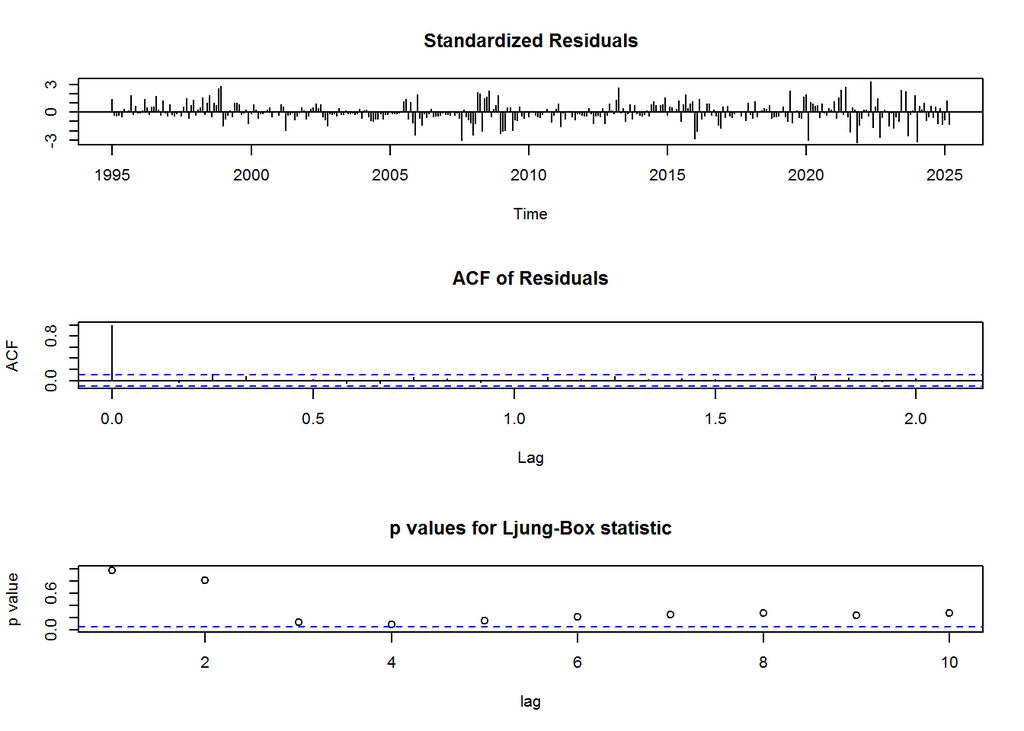

```r
tsdiag(arimatc)
```

Generamos los residuales del modelo ARIMA (ecuacion de media) y los graficamos.

La grafica muestra claramente procesos agrupados de volatilidad. Lo que nos indica que nuestra ecuacion de media tiene heteroscedastidad.

```r
res.arima=arimatc$residuals
hchart(res.arima) %>%
  hc_title(text = "Residuales del ARIMA 1995-2025")%>%
  hc_legend(enabled = FALSE)
```

[interactive chart not shown]

**Pruebas de normalidad de la ecuacion de media ARIMA(1,0,0)**

*Jarque-Bera*

| Hipotesis: |  |
| --- | --- |
| H<sub>0</sub>: | La muestra proviene de una distribución normal > 0.05 |
| H<sub>1</sub>: | La muestra no proviene de una distribución normal < 0.05 |

```r
jarque.bera.test(res.arima)
```

```
    Jarque Bera Test

data:  res.arima
X-squared = 27.492, df = 2, p-value = 1.072e-06
```

*Shapiro-Wilk*

| Hipotesis: |  |
| --- | --- |
| H<sub>0</sub>: | La muestra proviene de una distribución normal > 0.05 |
| H<sub>1</sub>: | La muestra no proviene de una distribución normal < 0.05 |

```r
shapiro.test(res.arima)
```

```
    Shapiro-Wilk normality test

data:  res.arima
W = 0.96985, p-value = 7.65e-07
```

## ARCH

Observemos un par de gráficas de la función de autocorrelación.

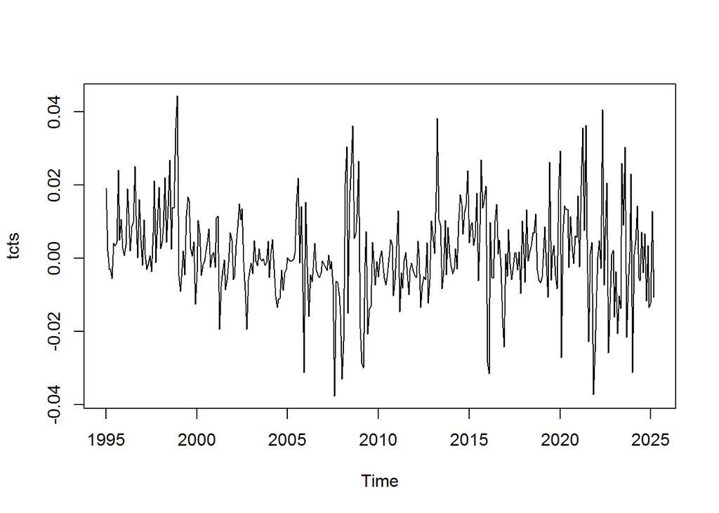

```r
plot(tcts)
```

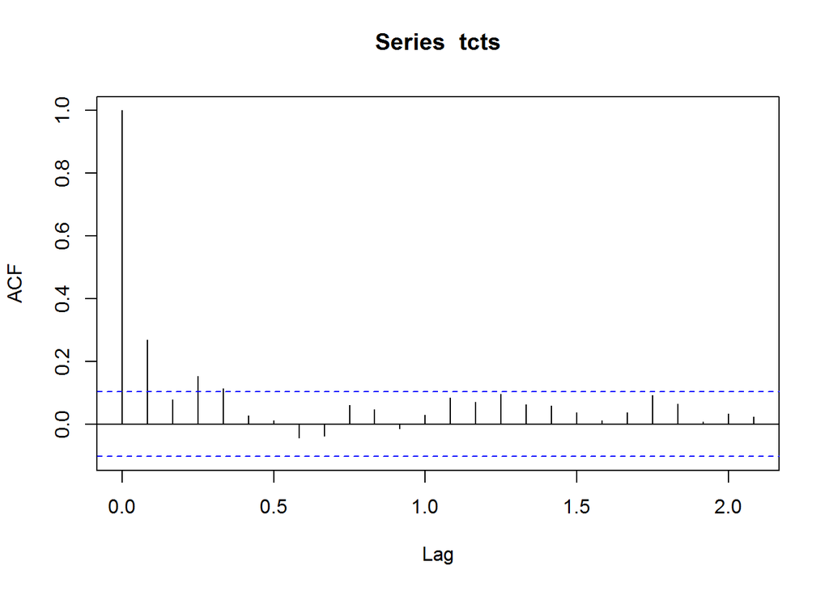

```r
acf(tcts)
```

La idea de clusterización de volatilidad, asume que periodos de alta volatilidad serán seguidos por una alta volatilidad y viceversa. Por esta razón la función de autocorrelación útil para saber si existen clusters de volatilidad es utilizando el valor absoluto, ya que lo que importa es saber si la serie está autocorrelacionada en la magnitud de los movimientos.

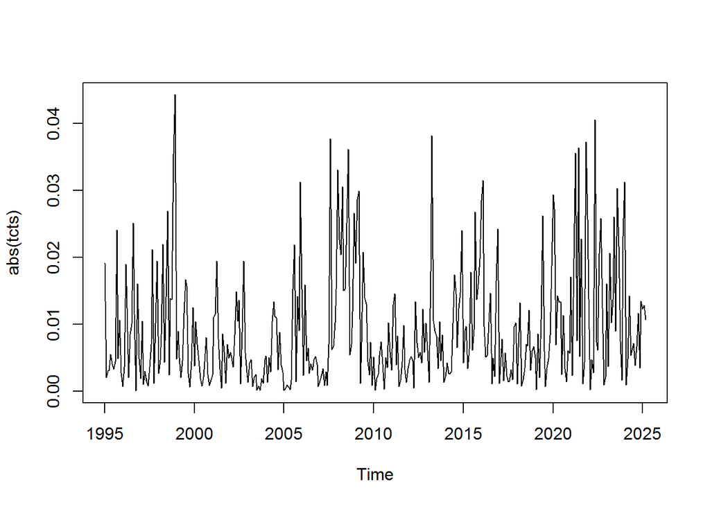

```r
plot(abs(tcts))
```

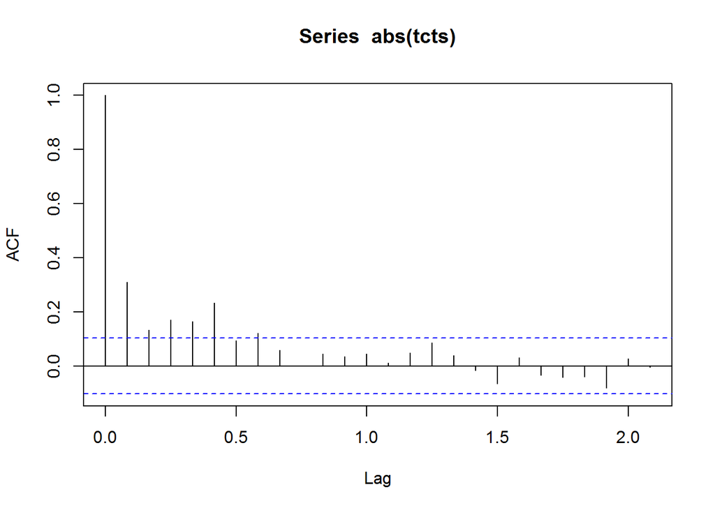

```r
acf(abs(tcts))
```

Otra manera de corroborar esta idea es volviendo IID nuestra serie de datos y observar que de este modo se pierde la autocorrelación serial, lo que refuerza la idea de que en esta serie existen clusters de volatilidad.

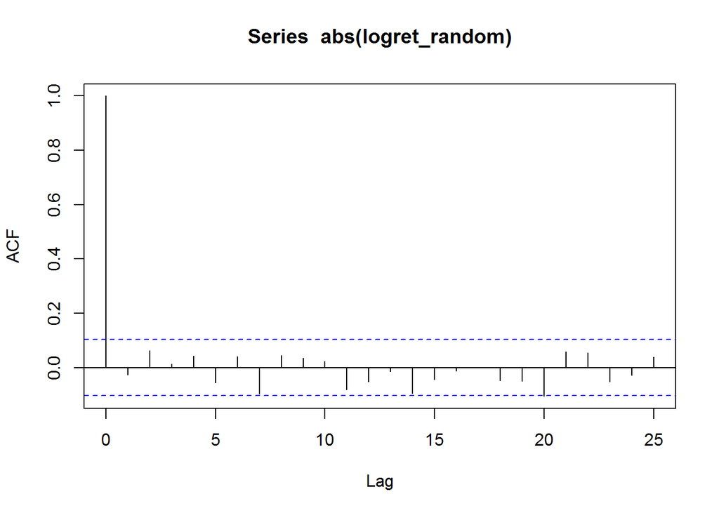

```r
logret_random = sample(as.vector(tcts), size =  length(tcrend), replace = FALSE)
acf(abs(logret_random))
```

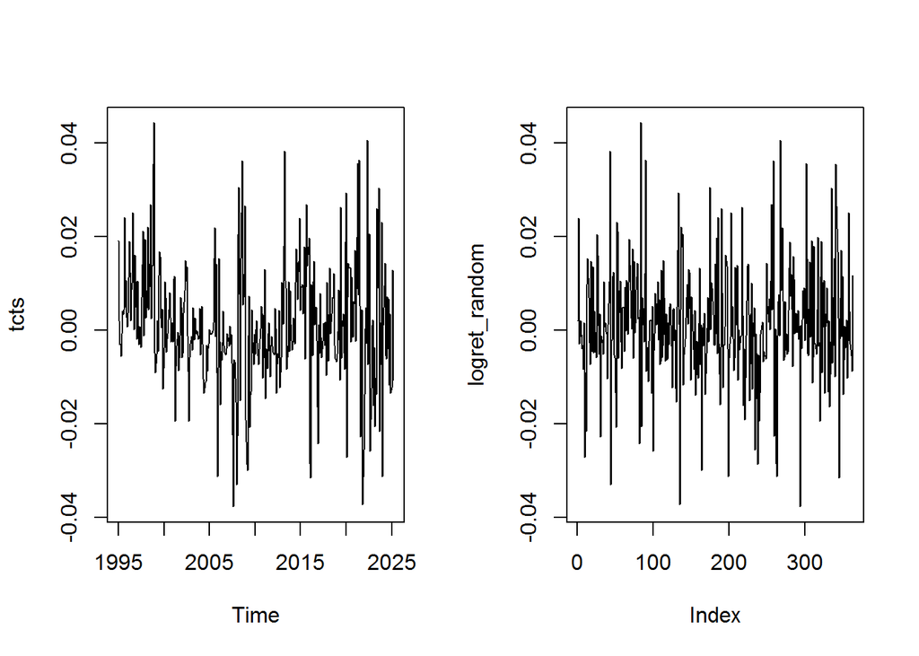

```r
par(mfrow = c(1,2))
plot(tcts, type='l')
plot(logret_random, type = 'l')
```

```r
#logret_mean = dynlm(tcrend~1)
#summary(logret_mean)
ehatsq = ts(resid(arimatc)^2)
ARCH_m = dynlm(ehatsq~L(ehatsq))
summary(ARCH_m)
```

```
Time series regression with "ts" data:
Start = 2, End = 363

Call:
dynlm(formula = ehatsq ~ L(ehatsq))

Residuals:
       Min         1Q     Median         3Q        Max
-4.034e-04 -1.137e-04 -9.363e-05 -3.110e-06  1.502e-03

Coefficients:
             Estimate Std. Error t value Pr(>|t|)
(Intercept) 1.138e-04  1.568e-05   7.257 2.45e-12 ***
L(ehatsq)   2.196e-01  5.140e-02   4.272 2.49e-05 ***
---
Signif. codes:  0 '***' 0.001 '**' 0.01 '*' 0.05 '.' 0.1 ' ' 1

Residual standard error: 0.000262 on 360 degrees of freedom
Multiple R-squared:  0.04824,   Adjusted R-squared:  0.0456
F-statistic: 18.25 on 1 and 360 DF,  p-value: 2.486e-05
```

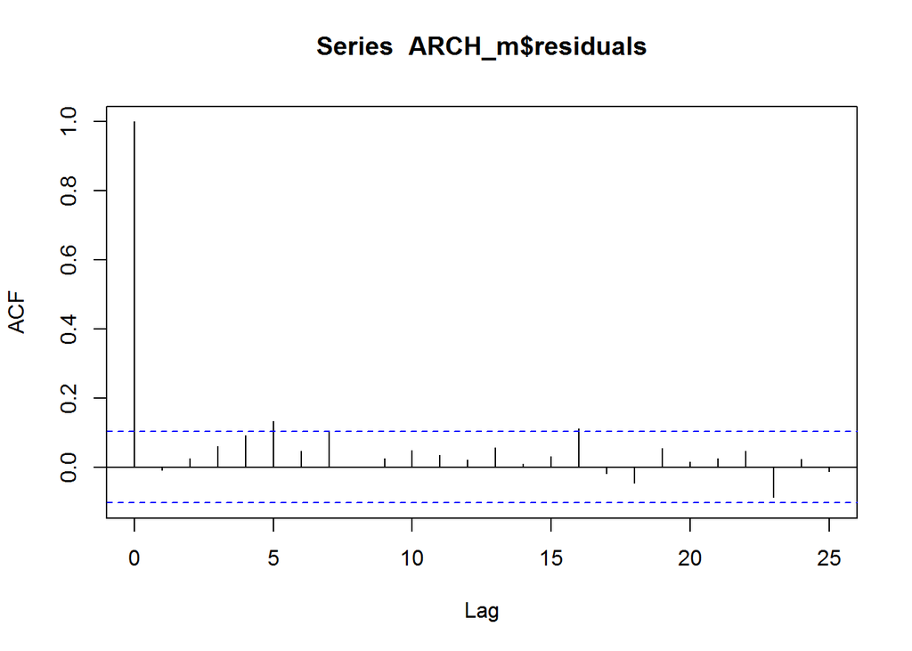

```r
acf(ARCH_m$residuals)
```

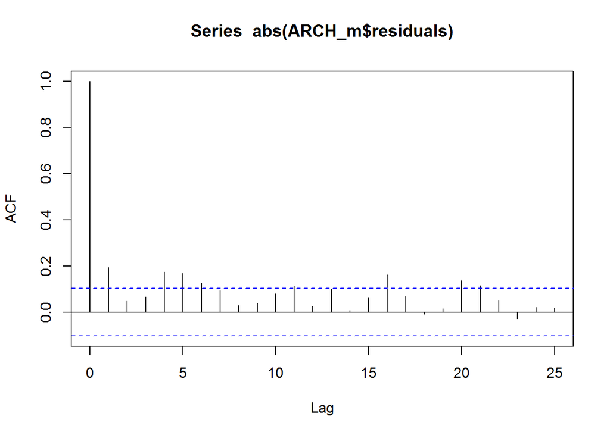

```r
acf(abs(ARCH_m$residuals))
```

Segundo enfoque para aceptar o rechazar la existencia de un ARCH es mediante un test. Observando el resultado de abajo, podemos comprobar que hay evidencia suficiente para rechazar la hipotesis nula de que no hay efectos ARCH.

| Hipotesis: |  |
| --- | --- |
| H<sub>0</sub>: | No hay efectos ARCH > 0.05 |
| H<sub>1</sub>: | Sí hay efectos ARCH < 0.05 |

```r
ArchTest(tcts, lags = 1, demean = TRUE)
```

```
    ARCH LM-test; Null hypothesis: no ARCH effects

data:  tcts
Chi-squared = 19.419, df = 1, p-value = 1.05e-05
```

## ARCH(1)

$Y_t = \mu+\sqrt{h_t}\varepsilon_t$

$h_t = \omega+\alpha_ih_{t-i}+u_t$

$\varepsilon$~$N(0,1)$

```r
library(rugarch)
#?ugarchspec
model.spec = ugarchspec( variance.model = list(model = 'sGARCH',
                        garchOrder = c(1, 0)),
                        mean.model = list(armaOrder = c(1,0)),
                        distribution.model = "std")
#?ugarchfit
arch.fit = ugarchfit(spec = model.spec , data = tcts, solver = 'solnp')
arch.fit@fit$matcoef
```

```
           Estimate   Std. Error  t value     Pr(>|t|)
mu     8.833475e-04 6.870018e-04 1.285801 1.985126e-01
ar1    3.418527e-01 5.340843e-02 6.400725 1.546412e-10
omega  7.083184e-05 1.434008e-05 4.939432 7.835061e-07
alpha1 8.319972e-01 2.552852e-01 3.259089 1.117706e-03
shape  4.612948e+00 1.172087e+00 3.935672 8.296419e-05
```

**Pronosticando un periodo hacia adelante con ARCH(1)**

```r
boot.arch = ugarchboot(arch.fit,
                         method = "Partial",
                         sampling = "raw",  #bootstrap from fitted varepsilon
                         n.ahead = 1,          #simulation horizon
                         n.bootpred = 100000, #number of simulations
                         solver = "solnp")
boot.arch
```

```
*-----------------------------------*
*     GARCH Bootstrap Forecast      *
*-----------------------------------*
Model : sGARCH
n.ahead : 1
Bootstrap method:  partial
Date (T[0]): mar. 2025

Series (summary):
          min      q.25      mean     q.75      max forecast[analytic]
t+1 -0.076099 -0.011355 -0.002116 0.006944 0.068004          -0.003093
.....................

Sigma (summary):
         min    q0.25     mean    q0.75      max forecast[analytic]
t+1 0.016619 0.016619 0.016619 0.016619 0.016619           0.016619
.....................
```

## GARCH(0,1)

$Y_t = \mu+\sqrt{h_t}\varepsilon_t$

$h_t = \omega+\beta_ih^2_{t-i}+u_t$

$\varepsilon$~$N(0,1)$

```r
model.spec = ugarchspec(variance.model = list(model = 'sGARCH',
                        garchOrder = c(0,1)),
                        mean.model = list(armaOrder = c(1,0)),
                        distribution.model = "std")
fit.garch.n = ugarchfit(spec = model.spec, data = tcts, solver = "solnp")
fit.garch.n@fit$matcoef
```

```
          Estimate   Std. Error     t value     Pr(>|t|)
mu    8.925193e-04 7.236979e-04   1.2332761 2.174728e-01
ar1   2.774083e-01 5.021048e-02   5.5249081 3.296582e-08
omega 7.427736e-07 1.158775e-06   0.6409987 5.215235e-01
beta1 9.989998e-01 1.184723e-03 843.2348351 0.000000e+00
shape 2.792679e+00 2.536398e-01  11.0104131 0.000000e+00
```

**Pronosticando un periodo hacia adelante con GARCH(1)**

```r
boot.garch = ugarchboot(fit.garch.n,
                         method = "Partial",
                         sampling = "raw",  #bootstrap from fitted varepsilon
                         n.ahead = 1,          #simulation horizon
                         n.bootpred = 100000, #number of simulations
                         solver = "solnp")
boot.garch
```

```
*-----------------------------------*
*     GARCH Bootstrap Forecast      *
*-----------------------------------*
Model : sGARCH
n.ahead : 1
Bootstrap method:  partial
Date (T[0]): mar. 2025

Series (summary):
         min     q.25      mean     q.75      max forecast[analytic]
t+1 -0.04582 -0.00853 -0.001691 0.005862 0.044137          -0.002337
.....................

Sigma (summary):
         min    q0.25     mean    q0.75      max forecast[analytic]
t+1 0.018113 0.018113 0.018113 0.018113 0.018113           0.018113
.....................
```

## Selección GARCH(p,q) óptimo

$Y_t = \mu+\sqrt{h_t}\varepsilon_t$

$h_t = \omega+\beta_ih_{t-i}+\alpha_i\varepsilon^2_{t-i}+u_t$

$\varepsilon$~$N(0,1)$

```r
#infocriteria(fit.garch.n)
#Selección del modelo óptimo
# Funcion para determinar los rezagos OPTIMOS de un GARCH:
Lag_Opt_GARCH = function(X_t,q_max, p_max){
  library(rugarch)
  # q_max: Rezagos maximos a evaluar del componente ARCH
  # p_max: Rezagos maximos a evaluar del componente GARCH
  # X_t: Serie de Tiempo modelada
  Criterio_AIC = matrix(rep(0, 4*((q_max)*p_max)), ncol = 4)
  colnames(Criterio_AIC) = c("q", "p", "AIC", "Optimo")
  grupo = 1
  for(i in 1:p_max){
    for(j in 1:q_max){
      Criterio_AIC[grupo,1] = i
      Criterio_AIC[grupo,2] = j
      model.spec = ugarchspec(variance.model = list(model = 'sGARCH',
      garchOrder = c(i,j)),
      mean.model = list(armaOrder = c(0,0)),
      distribution.model = "std")
      model = ugarchfit(spec = model.spec, data = X_t)
      Criterio_AIC[grupo,3] = infocriteria(model)[1]
      grupo = grupo + 1
    }
  }
  Optimo = min(Criterio_AIC[1:(p_max*q_max),3])
  for(i in 1:(p_max*q_max)){
    if(Criterio_AIC[i,3] == Optimo){
      Criterio_AIC[i,4] <- 1
    }
  }
  return(Criterio_AIC)
  #
}
#source("Lag_Opt_GARCH.R")
Lag_Opt_GARCH(ehatsq,4,4)
```

```
      q p       AIC Optimo
 [1,] 1 1 -14.50764      1
 [2,] 1 2 -14.48772      0
 [3,] 1 3 -14.47585      0
 [4,] 1 4 -14.46162      0
 [5,] 2 1 -14.47854      0
 [6,] 2 2 -14.46671      0
 [7,] 2 3 -14.45246      0
 [8,] 2 4 -14.43956      0
 [9,] 3 1 -14.46404      0
[10,] 3 2 -14.44437      0
[11,] 3 3 -14.43485      0
[12,] 3 4 -14.42246      0
[13,] 4 1 -14.44502      0
[14,] 4 2 -14.43217      0
[15,] 4 3 -14.42166      0
[16,] 4 4 -14.41091      0
```

```r
# Estimación de modelo óptimo
model.spec = ugarchspec(variance.model = list(model = 'sGARCH' ,
             garchOrder = c(1,1)), mean.model = list(armaOrder = c(1,0)),
             distribution.model = "std")
model.fit = ugarchfit(spec = model.spec , data = tcts, solver = 'solnp')
model.fit@fit$matcoef
```

```
           Estimate   Std. Error  t value     Pr(>|t|)
mu     7.300213e-05 7.190277e-04 0.101529 9.191306e-01
ar1    3.166893e-01 5.653238e-02 5.601911 2.120017e-08
omega  1.546241e-05 6.101250e-06 2.534303 1.126714e-02
alpha1 4.614457e-01 1.492256e-01 3.092270 1.986323e-03
beta1  5.375529e-01 9.095613e-02 5.910024 3.420576e-09
shape  5.012655e+00 1.428942e+00 3.507950 4.515742e-04
```